# Introduction to Python

# Visualization

- plot with `matplotlib`
- build a line plot and a bar chart
- add titles, axis labels, legends

## Matplotlib

The base plotting library — seaborn and others build on it.

```
import matplotlib.pyplot as plt
```

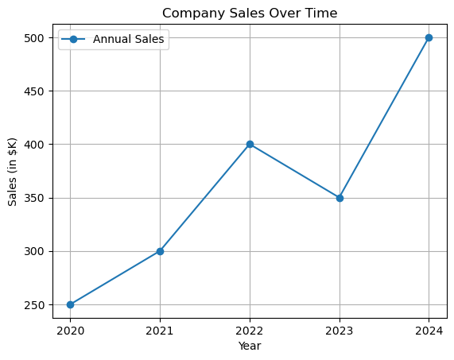

```python
### Simple line plot

import matplotlib.pyplot as plt

# Example data
years = ["2020", "2021", "2022", "2023", "2024"]
sales = [250, 300, 400, 350, 500]

# Create a line plot
plt.plot(years, sales, marker='o', label='Annual Sales')

# Add title, labels, legend
plt.title("Company Sales Over Time")
plt.xlabel("Year")
plt.ylabel("Sales (in $K)")
plt.legend()
plt.grid(True)
plt.show()
```

## Bar chart

Best for comparing categories.

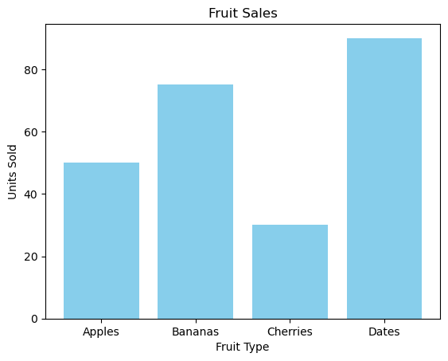

```python
categories = ["Apples", "Bananas", "Cherries", "Dates"]
values = [50, 75, 30, 90]

plt.bar(categories, values, color="skyblue")
plt.title("Fruit Sales")
plt.xlabel("Fruit Type")
plt.ylabel("Units Sold")
plt.show()
```

# Mini project · The Phillips curve

Real data, start to finish:

- pull two series from FRED
- clean and merge them with pandas
- summary statistics and a correlation
- plot inflation against unemployment

## 1 · Setup

```python
!pip install pandas_datareader
```

```python
import pandas as pd
import numpy as np
import matplotlib.pyplot as plt
from datetime import datetime
import pandas_datareader.data as web
```

## 2 · Load the FRED data

- `CPIAUCSL` — Consumer Price Index, seasonally adjusted (a level, not a rate)
- `UNRATE` — unemployment rate, percent

We convert CPI into year-over-year inflation.

```python
# Define date range (feel free to adjust)
start = datetime(2015, 1, 1)
end   = datetime(2025, 12, 31)

# Read series from FRED
cpi = web.DataReader("CPIAUCSL", "fred", start, end)
print(cpi.head())
unr = web.DataReader("UNRATE",   "fred", start, end)
print(unr.head())

# Compute year-over-year inflation rate (%)
cpi['Inflation'] = cpi['CPIAUCSL'].pct_change(12) * 100
print(cpi.head())

# Merge on date index
df = pd.concat([cpi['Inflation'], unr['UNRATE']], axis=1).dropna()
df.columns = ['Inflation', 'Unemployment']

df.info()
```

### What the code does

1. `datetime(Y, M, D)` sets the date range.
2. `web.DataReader(symbol, "fred", start, end)` fetches each series, indexed by date.
3. `pct_change(12)` takes the 12-month change; ×100 makes it percent. The first 12 rows are `NaN`.

   $\text{Inflation}_t = \dfrac{CPI_t - CPI_{t-12}}{CPI_{t-12}} \times 100$
4. `pd.concat(..., axis=1)` merges on the shared date index; `dropna()` clears the leading `NaN`s.

Needs `pip install pandas-datareader`.

## 3 · Summary statistics and correlation

```python
print("Summary statistics:")
display(df.describe())

corr = df['Inflation'].corr(df['Unemployment']) # Pearson correlation by default
print(f"Correlation between Inflation and Unemployment: {corr:.3f}")
```

## 4 · Time Series Plot

One plot per series, for clarity.

```python
# Inflation over time
plt.figure()
plt.plot(df.index, df['Inflation'])
plt.title("Inflation Rate")
plt.xlabel("Year")
plt.ylabel("Percent")
plt.grid(True)
plt.tight_layout()
plt.show()
```

```python
# Unemployment over time
plt.figure()
plt.plot(df.index, df['Unemployment'])
plt.title("Unemployment Rate (%)")
plt.xlabel("Year")
plt.ylabel("Percent")
plt.grid(True)
plt.tight_layout()
plt.show()
```

## 5 · The Phillips curve

Inflation (y) against unemployment (x), with a least-squares line from `numpy.polyfit`.

```python
x = df['Unemployment'].to_numpy()
y = df['Inflation'].to_numpy()

# Linear fit: y = m*x + b
m, b = np.polyfit(x, y, 1) # np.polyfit with degree=1 returns slope m and intercept b (least squares)

# creates 100 evenly spaced points from a to b to draw a smooth fitted line.
line_x = np.linspace(x.min(), x.max(), 100)
line_y = m * line_x + b

plt.figure()
plt.scatter(x, y, alpha=0.6, label="Monthly observations")
plt.plot(line_x, line_y, label=f"OLS fit: y = {m:.2f}x + {b:.2f}")
plt.title("Phillips Curve: Inflation vs. Unemployment")
plt.xlabel("Unemployment Rate (%)")
plt.ylabel("Inflation Rate (YoY, %)")
plt.legend()
plt.grid(True)
plt.tight_layout()
plt.show()
```

- `np.polyfit(x, y, 1)` returns slope `m` — inflation change per 1pp of unemployment — and intercept `b`
- `np.linspace(a, b, 100)` gives evenly spaced points to draw the fitted line
- `alpha=0.6` keeps dense clusters readable; `tight_layout()` fixes label spacing